# Introduction to R

Master 1 Economy & Psychology — Paris-Cité — 2025-2026

Charly Marie

charly.marie.pro@gmail.com

October 17, 2025

# 1 Lecture organisation

## We only have three hours, but we’ll make the most of them!

- This course introduces R, which is both
  - A programming language
  - A software
- We only have three hours. Therefore, you will not be manipulating data in this class. Instead, the course provides you with a toolbox
  - Researchers mostly follow the same steps in each data analysis project: import data, clean and prepare data, describe data, analyse data, plot data, export the plots and results
  - Slides represent a function that is essential for the first three steps
  - (Free) online resources are provided for the last three steps
- My aim is for you to grasp the fundamentals of R so that you can reuse the functions I demonstrate and train yourself using free online resources

# 2 The (very) basics of R

[figure not shown]

From Denise Earle on [X](https://x.com/deniseearle/status/1465971899415023617)

## Why use R ?

- R is an important tool for many data analysts who use it to prepare, analyse and plot data, as well as create websites, reports and presentations (like this one, which was made entirely in R). But most importantly, it
  - is free
  - is open-source
  - allows anyone to reproduce your results (see, for instance, the [Institute For Replication](https://i4replication.org/))
  - is very powerful *and* flexible
  - has a very engaged community that you can ask for help

[figure not shown]

## R’s logic

- R is basically a big fancy calculator

[figure not shown]

## R’s logic

- R is basically a big fancy calculator

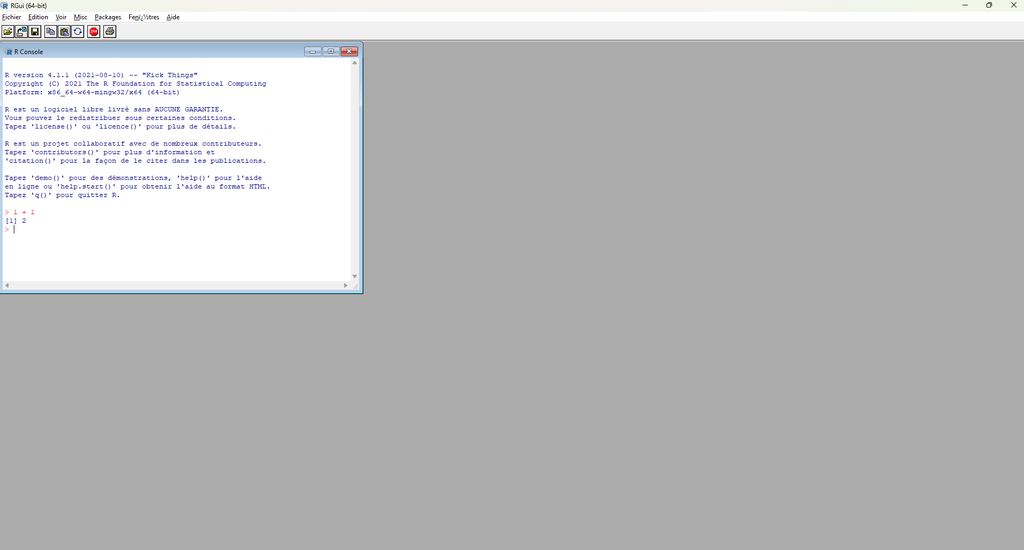

## Very few people use base R, most use an Integrated Development Environment (IDE) such as [RStudio](https://posit.co/download/rstudio-desktop/)

[figure not shown]

## Very few people use base R, most use an Integrated Development Environment (IDE) such as [RStudio](https://posit.co/download/rstudio-desktop/)

[figure not shown]

## Very few people use base R, most use an Integrated Development Environment (IDE) such as [RStudio](https://posit.co/download/rstudio-desktop/)

[figure not shown]

## Very few people use base R, most use an Integrated Development Environment (IDE) such as [RStudio](https://posit.co/download/rstudio-desktop/)

[figure not shown]

## Very few people use base R, most use an Integrated Development Environment (IDE) such as [RStudio](https://posit.co/download/rstudio-desktop/)

[figure not shown]

**Tip**

R is designed for scripts. Write your code in scripts, so that you can: (1) track everything you have done; (2) reproduce everything you have done; (3) share everything you have done.

## Very few people use base R, most use an Integrated Development Environment (IDE) such as [RStudio](https://posit.co/download/rstudio-desktop/)

- Pro tip: the first time you use RStudio, go to Tools –> Global Options… and
  1. Untick the box *Restore .RData into workspace at startup*
  2. Set *Save workspace to .RData on exit* to *Never*
  - I really advise you to do this so that each time you open a new R session, you start with a brand new, empty environment. Imagine still having loaded data named `expe1` and not understanding why the right columns are not showing? Been there, done that

[figure not shown]

## R is an object-oriented language

- R is essentially a **big, fancy calculator**
  - Do you want to find $\hat{\boldsymbol{\beta}} = \underset{\boldsymbol{\beta}}{\arg\min} \; \sum_{i=1}^{n} \big(y_i - \mathbf{x}_i^\top \boldsymbol{\beta}\big)^2$ ? It can do that for you — if you know how to ask!
- R works with **objects**. Objects can be (almost) anything
  - A single number or multiple numbers
  - A single character or character string (a word, multiple words, a sentence, multiple sentences, etc.)
  - A data frame comprising numbers and character strings
  - A plot
  - The output of a Generalised Random Forest
  - And, most importantly, all of the above, nested like Russian dolls 🪆
- Combine a calculator with objects and you get the essence of R: a large calculator that manipulates objects

## R is basically a big (fancy) calculator

```r
# Addition
1 + 1
```

```
[1] 2
```

```r
# Subtraction
19 - 8
```

```
[1] 11
```

```r
# Division
log(x = 98) / sqrt(x = 108)
```

```
[1] 0.4411887
```

```r
# Multiplication
78^83 * (1 / log(x = sqrt(x = 32^3), base = exp(1)))
```

```
[1] 2127969009576438321662422224286864628246682226688202424468224488848044260660204006846282880004802664460642226688200044466840040824846488266880020484242462244
```

**Tip**

Anything that comes after a `#` in an R script is a comment that will never be run by R.

Comments are very useful for remembering why and how you wrote your script and for explaining it to yourself and others (think *reproducibility*).

[figure not shown]

From [R Memes For Statistical Fiends](https://www.facebook.com/photo/?fbid=4530293413689581&set=a.1230204967031792)

## R is basically a big (fancy) calculator that manipulates objects

```r
adding_1 <- 1 + 1
subtract_1 <- 19 - 8
divide_1 <- log(x = 98, base = exp(1)) / sqrt(x = 108)
multiply_1 <- 78^83 * (1 / log(x = sqrt(x = 32^3), base = exp(1)))

adding_1 + subtract_1 / (divide_1 * multiply_1)
```

```
[1] 2
```

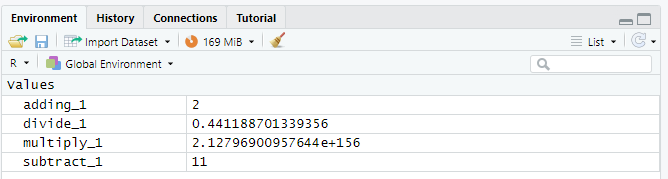

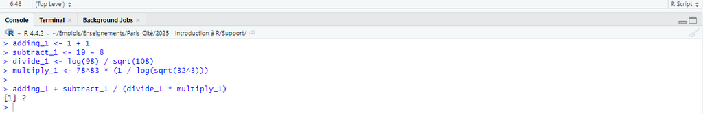

**Notes**

1. The `<-` operator means that I am assigning what is on the right of the operator to the object that is on the left of the operator.
2. When defining and manipulating objects, R (1) stores them in the Environment window; and (2) prints the used code and the answer in the Console window.
3. Always use lowercase letters when naming your objects (R is case-sensitive) and avoid using diacritics or special characters. A good, albeit slightly long, name is `lm_income_by_age_robustness_trimmed_1_99`. This is a VERY BAD name: `Predictor_âge_Sexe_robustness1_sansélèvesdéfaillants`. Technically, it works. However, you’ll find yourself having to try very hard to write it correctly every time you need to.

## Functions are a central element to R, that builds on objects

```r
x <- c(10, 4, 7, 12, 3, 18, 4, 12, 8) # Manually define an object x that takes multiple values

sqrt(x = x)
```

```
[1] 3.162278 2.000000 2.645751 3.464102 1.732051 4.242641 2.000000 3.464102
[9] 2.828427
```

**Note**

In this case, the function only takes one argument, x. Usually, a function takes multiple arguments (x, y, dataframe, etc.).

## Functions are a central element to R, that builds on objects

- Functions are objects that
  - Take an input with arguments
  - Follow a series of instructions given arguments
  - Provide an output given arguments
- For example, imagine you want to **find the lowest value in a given column, add its line number, and then multiply the result by the time of day**. You could write a function to perform this task

```r
x <- c(10, 4, 7, 12, 3, 18, 4, 12, 8) # Manually define an object x that takes multiple values

min_x <- function(x) {                          # Take the object x as an input
  i <- which.min(x)                             # Find the smallest value of x
  val <- x[i] + i                               # Add the line number to the smallest value
  val * as.numeric(format(Sys.time(), "%H"))    # Multiply the result by the hour of the day (0–23)
}

min_x(x = x)
```

```
[1] 104
```

**Note**

In this case, the function only takes one argument, x. Usually, a function takes multiple arguments (x, y, dataframe, etc.).

## Packages or libraries contain functions that perform calculations by manipulating objects

- Packages are collections of functions, dataframes and documentation that come together
  - Some packages are built into R and are part of what is called `base R`
  - Some packages need to be downloaded. These are known as `contributed packages` and are extremely useful
- Very few people work in base R. Those who do so do so because they
  - Need the full flexibility of R. For instance, Offer-Westort, Rosenzweig, and Athey (2024) wrote an adaptive assignment algorithm based on balanced linear Thompson sampling in base R, and [their code can be accessed online](https://github.com/gsbDBI/infodemic-replication)
  - Need full control and reproducibility over their analyses. National statistics organisations such as INSEE mostly use base R because they cannot afford their statistics to be altered if an update to a package changes its calculation method

```r
install.packages("tidyverse") # Install a package
library("tidyverse")          # Load    a package
```

**Note**

Simply installing a package is not enough: you also need to load it *each time you launch a new session*.

### Find out how to get the most out of packages

- Packages can be *very* powerful. Make the most of them!
  - *At least*, they come with a Github. Just do a Google Search, and you will find their Github. Unfortunately, the github contains more or less informations about the functions and their arguments
  - Here, the `dplyr` [package](https://github.com/tidyverse/dplyr)

[figure not shown]

[figure not shown]

### Find out how to get the most out of packages

[figure not shown]

### Find out how to get the most out of packages

[figure not shown]

- Most of the packages pages follow the same structure
  - **Get started** provides an introduction to the package, offering a summary of its key objectives and functions alongside relevant R code
  - **Reference** gathers all functions in one place
  - **Articles** shows how to perform the package’s main functions, with accompanying R code
  - **News** section is the changelog file that tracks all changes for every new release of the package

## Packages or libraries contain functions that perform calculations by manipulating objects

[figure not shown]

By Albert Y. Kim on [X](https://x.com/rudeboybert/status/866442948560531456/photo/1)

# 3 Load a dataframe

## You are (almost) ready to load your first dataframe: a Comma-Separated Values (CSV) file

- Most of the data that you’ll use will be in the same formats
  - **CSV** or **TXT**. The most used ones for psychologists. Easy to share, light, easy to import/export.
  - **XLSX**. Excel’s format. Also easy to share and to export, although a bit more heavy. Does not have an advantaged over CSV *to share a dataframe*
  - **SAV**, or **SAS**, or **DTA**. Respectively, SPSS’s, SAS’, and Stata’s formats. You’ll learn how to use it when you need to, using the `haven` [package](https://haven.tidyverse.org/)
  - **PARQUET**, a file format specifically designed for (very) large data sets (more information [here](https://www.tidyverse.org/blog/2024/06/nanoparquet-0-3-0/)). Again, you’ll learn how to use it when you need to, using the `nanoparquet` [package](https://nanoparquet.r-lib.org/)
- Why *almost* ready ? Because we have not yet talked about the *Working directory*
  - R needs to be told everything, including were to load the data from. My best advice is to work with R projects
  - R Projects are *.Rproj* files that make your life much easier. Essentially, it tells R what your working directory is, so that you can work with a folder (and subfolders) for each of your data analysis project

### Work with R Projects

- To define a new R Project, go to File –> New Project… and follow the steps

[figure not shown]

- An alternative is to define the working directory manually. I am not fond of this approach, as it can be cumbersome and vulnerable to even minor changes in the directory file

```r
setwd("C:/Users/jaime/OneDrive/Documents/Emplois/Enseignements/Paris-Cité/2025 - Introduction à R/Support")
```

## You are ready to load your first dataframe: a Comma-Separated Values (CSV) file

- I have downloaded a dataframe and saved it is in the folder *Data* that is in my working directory
  - Dataframe is called *penguins.csv* and contains data about 344 penguins (Horst, Hill, and Gorman 2020). You can also get it [there](https://allisonhorst.github.io/palmerpenguins/)

```r
df <- read.table(file = "Data/penguins.csv",
                 header = TRUE,
                 sep = ",",
                 row.names = "X")
```

**Note**

Errors may occur when loading data. CSV files can be temperamental, and there are multiple standards in use. The reason for this is that some standards use commas `,` as column separators, while some use semicolons `;`. Moreover, some standards use periods `.` as decimal points and some use commas `,` as decimal points. Sometimes you need to dig in manually. This could be due to the column separator (does it use tabulation?), because the file contains row names that you did not specify (are you using a small x instead of a capital X?), etc… It can be a bit cumbersome — we’ve all been there!

**Tip**

You can make your life much easier by using File –> Import Dataset 😉

### Before we go any further, let’s take a closer look at the `read.table()` function

```r
df <- read.table(file = "Data/penguins.csv",
                 header = TRUE,
                 sep = ",",
                 row.names = "X")
```

- A **function** takes **arguments**
  - Learn more about a function by typing `?read.table()` in the console
  - Documentation displays the default options (`header = FALSE`). Arguments with no option in the documentation indicate that a value is required
  - `file =` part is not necessary, **as long as you respect the order of the arguments**
  - `""` are necessary to indicate a string. Else, R will consider that `Data/penguins.csv` is an object
  - Arguments requiring true or false segments can either take `TRUE` or `T`; `FALSE` or `F`

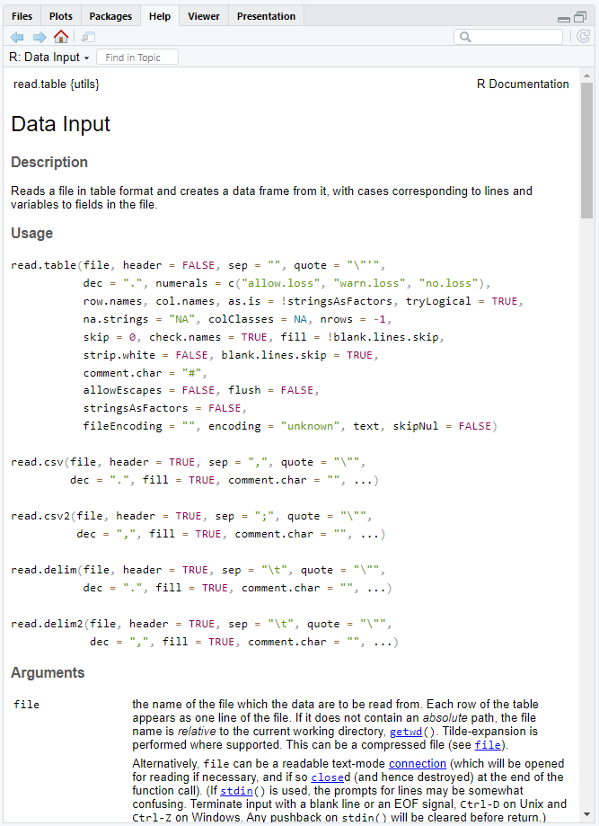

## Check the importation of your first dataframe

- `colnames()` returns the name of the columns (which are vectors)

```r
colnames(x = df)
```

```
[1] "species"           "island"            "bill_length_mm"
[4] "bill_depth_mm"     "flipper_length_mm" "body_mass_g"
[7] "sex"               "year"
```

## Check the importation of your first dataframe

- `nrow()` and `ncol()` respectively return the number of rows and of columns

```r
nrow(x = df)
```

```
[1] 344
```

```r
ncol(x = df)
```

```
[1] 8
```

## Check the importation of your first dataframe

- `head()` returns the first rows of an object

```r
head(x = df)
```

```
  species    island bill_length_mm bill_depth_mm flipper_length_mm body_mass_g
1  Adelie Torgersen           39.1          18.7               181        3750
2  Adelie Torgersen           39.5          17.4               186        3800
3  Adelie Torgersen           40.3          18.0               195        3250
4  Adelie Torgersen             NA            NA                NA        <NA>
5  Adelie Torgersen           36.7          19.3               193        3450
6  Adelie Torgersen           39.3          20.6               190        3650
     sex year
1   male 2007
2 female 2007
3 female 2007
4   <NA> 2007
5 female 2007
6   male 2007
```

## Check the importation of your first dataframe

- `str()` returns the structure of the object

```r
str(object = df)
```

```
'data.frame':   344 obs. of  8 variables:
 $ species          : chr  "Adelie" "Adelie" "Adelie" "Adelie" ...
 $ island           : chr  "Torgersen" "Torgersen" "Torgersen" "Torgersen" ...
 $ bill_length_mm   : num  39.1 39.5 40.3 NA 36.7 39.3 38.9 39.2 34.1 42 ...
 $ bill_depth_mm    : num  18.7 17.4 18 NA 19.3 20.6 17.8 19.6 18.1 20.2 ...
 $ flipper_length_mm: int  181 186 195 NA 193 190 181 195 193 190 ...
 $ body_mass_g      : chr  "3750" "3800" "3250" NA ...
 $ sex              : chr  "male" "female" "female" NA ...
 $ year             : int  2007 2007 2007 2007 2007 2007 2007 2007 2007 2007 ...
```

- `chr`, `num` and `int` indicate the type of data (vectors) that the dataframe contains

**Note**

Can you spot the error(s) ?

## Check the importation of your first dataframe

- `summary()` returns a summary of the object

```r
summary(object = df)
```

```
   species             island          bill_length_mm  bill_depth_mm
 Length:344         Length:344         Min.   :32.10   Min.   :13.10
 Class :character   Class :character   1st Qu.:39.23   1st Qu.:15.60
 Mode  :character   Mode  :character   Median :44.45   Median :17.30
                                       Mean   :43.92   Mean   :17.15
                                       3rd Qu.:48.50   3rd Qu.:18.70
                                       Max.   :59.60   Max.   :21.50
                                       NA's   :2       NA's   :2
 flipper_length_mm body_mass_g            sex                 year
 Min.   :172.0     Length:344         Length:344         Min.   :2007
 1st Qu.:190.0     Class :character   Class :character   1st Qu.:2007
 Median :197.0     Mode  :character   Mode  :character   Median :2008
 Mean   :200.9                                           Mean   :2008
 3rd Qu.:213.0                                           3rd Qu.:2009
 Max.   :231.0                                           Max.   :2009
 NA's   :2
```

## Check the importation of your first dataframe

- `describe()`, well… describes the object

```r
library(psych)
describe(x = df)
```

```
                  vars   n    mean    sd  median trimmed   mad    min    max
species*             1 344    1.92  0.89    2.00    1.90  1.48    1.0    3.0
island*              2 344    1.66  0.73    2.00    1.58  1.48    1.0    3.0
bill_length_mm       3 342   43.92  5.46   44.45   43.91  7.04   32.1   59.6
bill_depth_mm        4 342   17.15  1.97   17.30   17.17  2.22   13.1   21.5
flipper_length_mm    5 342  200.92 14.06  197.00  200.34 16.31  172.0  231.0
body_mass_g*         6 342   44.87 24.67   42.00   44.19 29.65    1.0   94.0
sex*                 7 333    1.50  0.50    2.00    1.51  0.00    1.0    2.0
year                 8 344 2008.03  0.82 2008.00 2008.04  1.48 2007.0 2009.0
                  range  skew kurtosis   se
species*            2.0  0.16    -1.73 0.05
island*             2.0  0.61    -0.91 0.04
bill_length_mm     27.5  0.05    -0.89 0.30
bill_depth_mm       8.4 -0.14    -0.92 0.11
flipper_length_mm  59.0  0.34    -1.00 0.76
body_mass_g*       93.0  0.24    -1.06 1.33
sex*                1.0 -0.02    -2.01 0.03
year                2.0 -0.05    -1.51 0.04
```

**Note**

`describe()` treats non-numerical data as numerical and indicates doing so with ✱. Be careful!

## Check the importation of your first dataframe

- `datasummary_skim()` describes the object, with a visual aid for numerical data

Unique

Missing Pct.

Mean

SD

Min

Median

Max

Histogram

bill_length_mm

165

1

43.9

5.5

32.1

44.5

59.6

[figure not shown]

bill_depth_mm

81

1

17.2

2.0

13.1

17.3

21.5

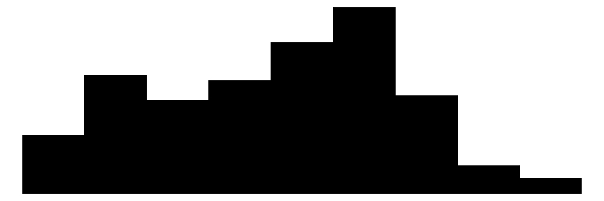

flipper_length_mm

56

1

200.9

14.1

172.0

197.0

231.0

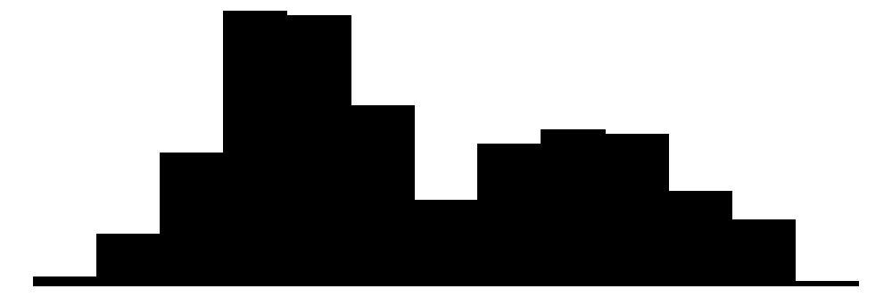

year

3

0

2008.0

0.8

2007.0

2008.0

2009.0

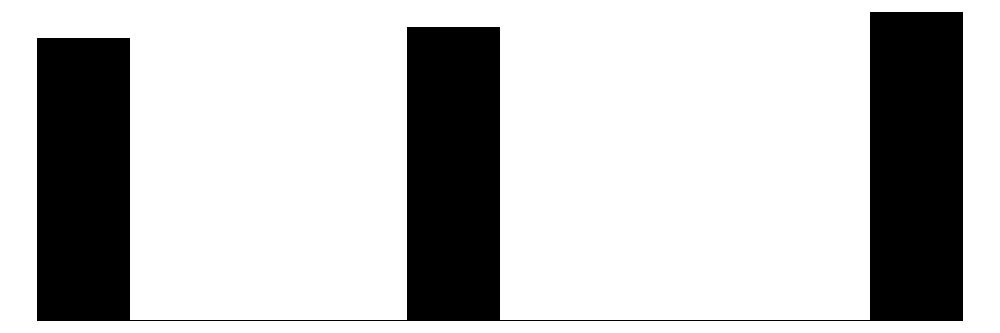

```r
library(modelsummary)
datasummary_skim(data = df, type = "numeric")
```

## Check the importation of your first dataframe

- `datasummary_skim()` describes the object

```r
datasummary_skim(data = df, type = "categorical")
```

|  |  | N | % |
| --- | --- | --- | --- |
| species | Adelie | 152 | 44.2 |
|  | Chinstrap | 68 | 19.8 |
|  | Gentoo | 124 | 36.0 |
| island | Biscoe | 168 | 48.8 |
|  | Dream | 124 | 36.0 |
|  | Torgersen | 52 | 15.1 |
| sex | female | 165 | 48.0 |
|  | male | 168 | 48.8 |
|  | NA | 11 | 3.2 |

**Caution**

`Warning: These variables were omitted because they include more than 50 levels: body_mass_g.`

**Notes**

If you cannot remember to which package a function belongs, for instance `datasummary_skim()`, you can type `??datasummary_skim()` in the console. This will take a while, as R will search through *every* package you have ever installed for the function.

### Check the importation of your first dataframe: The types of data

- There are six different types of vector, each relating to a different kind of data
  - **Numeric**. Mostly, it is numbers with a decimal
  - **Integer**. Whole numbers (no decimal)
  - **Logical**. `TRUE` or `FALSE` data. Can also take values `NA` or not, representing Missing Values
  - **Complex**. Complex numbers. We won’t cover it, my brain already hurts ($i^2 = -1 \text{ ?!}$)
  - **Character**. String values, whether letters, words, sentences… When ordered, characters become factors (for instance, Never; Sometimes; Always is an ordered factor, or ordered character)
  - **Raw**. We won’t cover it, as it is not used 99.99% of the time
- These types of data are stored in **vectors**, which are R’s fundamental data structure. When it comes to data, in R, everything is either a vector or an aggregate of vectors

### Check the importation of your first dataframe: Modify the type of data

- R is usually able to assign the correct data type to a vector. However, as you saw, it failed for the `body_mass_g` column, treating it as a character rather than a numeric value
  - Question: Why is this a problem?
  - Let’s reassign it. Remember when I said there are *base R* and *contributed packages*? I’ll show you two ways to do the same operation

```r
df$body_mass_g <- as.integer(x = df$body_mass_g)

str(object = df$body_mass_g)
```

```
 int [1:344] 3750 3800 3250 NA 3450 3650 3625 4675 3475 4250 ...
```

```r
df <- df %>%
  mutate(body_mass_g = as.integer(body_mass_g))
str(object = df$body_mass_g)
```

```
 int [1:344] 3750 3800 3250 NA 3450 3650 3625 4675 3475 4250 ...
```

**Notes**

1. Use the `$` sign to access vectors stored in objects, such as a dataframe. This method is not 100% reliable, depending on the structure of the object, but you will learn as you go along.
2. Most of the time, you don’t need to work in base R to manipulate data. You will learn to use the `tidyverse` packages (Wickham et al. 2019), which will make your data manipulation much easier.

```r
summary(object = df$body_mass_g)
```

```
   Min. 1st Qu.  Median    Mean 3rd Qu.    Max.    NA's
   2700    3550    4050    4202    4750    6300       2
```

# 4 How to manipulate data: The `tidyverse` and the pipe operator `%>%`

[figure not shown]

## The tidyverse is a suite of packages intended to make data manipulation much easier

- Again, everything can be done in base R. But, some manipulations are highly cumbersome in base R. To ease data wrangling, a suite of packages (and functions) were made under the name **tidyverse**
  - The tidyverse follows a *philosophy of data* (Wickham 2014)
  1. Each variable forms a column
  2. Each observation forms a row (not a person: an observation)
  3. Each type of observational unit forms a table

```r
install.packages("tidyverse") # Install a package
library("tidyverse")          # Load    a package
```

[figure not shown]

## Before manipulating data: The pipe operator `%>%`

- R works using nested expressions from the inside out. It can get quite ridiculous somehow. To avoid doing so, a **pipe** operator has been created
- Base R

```r
mean(x =
  sqrt(x =
    abs(x =
      log(x =
        as.numeric(x =
          factor(x = c(-10, 0, 10, 100),
                 levels = c(-10, 0, 10, 100))
        )
      )
    )
  )
)
```

```
[1] 0.7645279
```

- Using the pipe operator

```r
c(-10, 0, 10, 100) %>%                         # Create a vector
  factor(levels = c(-10, 0, 10, 100)) %>%      # convert to factor
  as.numeric() %>%                             # factor → numeric
  log() %>%                                    # take log
  abs() %>%                                    # absolute value
  sqrt() %>%                                   # square root
  mean()                                       # mean of the result
```

```
[1] 0.7645279
```

- The `%>%` operator takes the object on its left side and makes it the first argument of the function on its right side. Said differently, R can now work linearly!
- Another pipe operator `|>` also exists. You can find a [summary of the main differences here](https://www.tidyverse.org/blog/2023/04/base-vs-magrittr-pipe/). Personally, I use the `%>%` operator out of habit, and also because it is easier to use with an AZERTY keyboard

### Rename vectors (columns in a dataframe)

- Let’s translate a column to French 🥖

```r
names(df)[names(df) == "species"] <- "Espèce"
```

```r
df <- df %>%
  rename("Espèce" = "species")
```

[figure not shown]

A tidyverse workflow, taken from Wickham, Cetinkaya-Rundel, and Grolemund (2023).

### Create a new vector (column in a dataframe), based on an existing one

- For example, what if I prefer to count in pounds rather than grams?

```r
df$body_mass_pounds <- df$body_mass_g / 453.59237
```

```r
df <- df %>%
  mutate(body_mass_pounds = body_mass_g / 453.59237)
```

- Get the mean and the standard deviation of this new column

```r
mean(x = df$body_mass_pounds)
```

```
[1] NA
```

```r
sd(x = df$body_mass_pounds)
```

```
[1] NA
```

- R needs to be told what to do with missing values (`NAs`)

```r
mean(x = df$body_mass_pounds, na.rm = TRUE)
```

```
[1] 9.263283
```

```r
sd(x = df$body_mass_pounds, na.rm = TRUE)
```

```
[1] 1.768007
```

### Filter a dataframe, according to a condition in a vector (column)

```r
df %>%
  filter(body_mass_g >= mean(body_mass_g)) %>%
  nrow()
```

```
[1] 0
```

```r
df %>%
  filter(body_mass_g >= mean(body_mass_g,
                             na.rm = TRUE)) %>%
  nrow()
```

```
[1] 149
```

### Pivot a dataframe: 1/2

- We sometimes need to pivot data in order to run a repeated measures analysis

| id | group | before | after |
| --- | --- | --- | --- |
| 1 | control | 40.48391 | 42.24692 |
| 2 | control | 52.06518 | 54.77531 |
| 3 | control | 53.46311 | 40.54112 |
| 4 | control | 52.94401 | 53.91534 |
| 5 | control | 53.86674 | 51.82061 |
| 6 | test | 45.80264 | 52.06510 |
| 7 | test | 54.11571 | 57.03168 |
| 8 | test | 49.76629 | 66.47595 |
| 9 | test | 56.28729 | 56.44203 |
| 10 | test | 53.39197 | 64.62119 |

### Pivot a dataframe: 2/2

- We sometimes need to pivot data in order to run a repeated measures analysis

```r
df_wide %>%
  pivot_longer(
    cols = c(before,
             after),
    names_to = "time",
    values_to = "value")
```

**Note**

A `pivot_wider()` function is also available, depending on the required pivoting.

| id | group | time | value |
| --- | --- | --- | --- |
| 1 | control | before | 40.48391 |
| 1 | control | after | 42.24692 |
| 2 | control | before | 52.06518 |
| 2 | control | after | 54.77531 |
| 3 | control | before | 53.46311 |
| 3 | control | after | 40.54112 |
| 4 | control | before | 52.94401 |
| 4 | control | after | 53.91534 |
| 5 | control | before | 53.86674 |
| 5 | control | after | 51.82061 |
| 6 | test | before | 45.80264 |
| 6 | test | after | 52.06510 |
| 7 | test | before | 54.11571 |
| 7 | test | after | 57.03168 |
| 8 | test | before | 49.76629 |
| 8 | test | after | 66.47595 |
| 9 | test | before | 56.28729 |
| 9 | test | after | 56.44203 |
| 10 | test | before | 53.39197 |
| 10 | test | after | 64.62119 |

# 5 Summarise data

## The base R functions `table()` and `prop.table()`

- R has a built-in `table()` function. It won’t get you very far, but it is sometimes enough to quickly skim through your data (check how many categories a column has; whether some categories need to be merged together; the number of observations per category…)

```r
df %>%
  select(sex, species) %>%
  table()
```

```
        species
sex      Adelie Chinstrap Gentoo
  female     73        34     58
  male       73        34     61
```

- You can get the percentages by adding the `prop.table()` function

```r
df %>%
  select(sex, species) %>%
  table() %>%
  prop.table() * 100
```

```
        species
sex        Adelie Chinstrap   Gentoo
  female 21.92192  10.21021 17.41742
  male   21.92192  10.21021 18.31832
```

**Careful!**

We did not check for missing data thoroughly enough. Reporting these tables without further exploring whether (and how much) data is missing would be a bold move.

## Summarise data, the tough way

```r
df %>%

  summarize(
    mean = mean(body_mass_g),
    sd = sd(body_mass_g),
    n = n(),
    se = sd / sqrt(n),
    confint_low = mean - 1.96 * se,
    confint_high = mean + 1.96 * se,
    .by = sex)
```

```
     sex     mean       sd   n       se confint_low confint_high
1   male 4545.685 787.6289 168 60.76689    4426.581     4664.788
2 female 3862.273 666.1720 165 51.86142    3760.624     3963.921
3   <NA>       NA       NA  11       NA          NA           NA
```

```r
df %>%
  drop_na() %>%
  summarize(
    mean = mean(body_mass_g),
    sd = sd(body_mass_g),
    n = n(),
    se = sd / sqrt(n),
    confint_low = mean - 1.96 * se,
    confint_high = mean + 1.96 * se,
    .by = sex)
```

```
     sex     mean       sd   n       se confint_low confint_high
1   male 4545.685 787.6289 168 60.76689    4426.581     4664.788
2 female 3862.273 666.1720 165 51.86142    3760.624     3963.921
```

- In this case, applying the `drop_na()` function to the entire dataset does not alter the results. However, most of the time it will. It would be better to do the following. Why?

```r
df %>%
  select(body_mass_g, sex) %>%
  drop_na() %>%
  summarize(
    mean = mean(body_mass_g),
    sd = sd(body_mass_g),
    n = n(),
    se = sd / sqrt(n),
    confint_low = mean - 1.96 * se,
    confint_high = mean + 1.96 * se,
    .by = sex)
```

```
     sex     mean       sd   n       se confint_low confint_high
1   male 4545.685 787.6289 168 60.76689    4426.581     4664.788
2 female 3862.273 666.1720 165 51.86142    3760.624     3963.921
```

### Summarise data, the tough way, but make it pretty(ish) using the `flextable()` package 1/2

| Sex | Mean body mass (g) | sd | Number of penguins | se | 95% confidence interval [lower] | 95% confidence interval [upper] |
| --- | --- | --- | --- | --- | --- | --- |
| Male | 4,545.68 | 787.63 | 168 | 60.77 | 4,426.58 | 4,664.79 |
| Female | 3,862.27 | 666.17 | 165 | 51.86 | 3,760.62 | 3,963.92 |

### Summarise data, the tough way, but make it pretty(ish) using the `flextable()` package 2/2

```r
# Install the package and load it
install.packages("flextable")
library("flextable")

# Construct the table
df %>%
  select(body_mass_g, sex) %>%
  drop_na() %>%
  summarize(
    mean = mean(body_mass_g),
    sd = sd(body_mass_g),
    n = n(),
    se = sd / sqrt(n),
    confint_low = mean - 1.96 * se,
    confint_high = mean + 1.96 * se,
    .by = sex) %>%

  rename("Sex" = "sex",
         "Mean body mass (g)" = "mean",
         "Number of penguins" = "n",
         "95% confidence interval [lower]" = "confint_low",
         "95% confidence interval [upper]" = "confint_high") %>%

  mutate(across(where(is.numeric), ~ round(.x, 2)),
         Sex = ifelse(test = Sex == "male", yes = "Male", no = "Female")) %>%

# Format the table
  flextable() %>%
  bold(part = "header") %>%
  autofit() # %>%
# save_as_docx(path = "/Tables/Penguins_table_1.docx") # Or save_as_html()
```

### Summarise data, the tough way, and export it to LaTeX using `knitr()` and `kableExtra()` packages

```r
library("knitr")
library("kableExtra")

df %>%
  select(body_mass_g, sex) %>%
  drop_na() %>%
  summarize(
    mean = mean(body_mass_g),
    sd = sd(body_mass_g),
    n = n(),
    se = sd / sqrt(n),
    confint_low = mean - 1.96 * se,
    confint_high = mean + 1.96 * se,
    .by = sex) %>%
  rename("Sex" = "sex",
         "Mean body mass (g)" = "mean",
         "Number of penguins" = "n",
         "95% confidence interval [lower]" = "confint_low",
         "95% confidence interval [upper]" = "confint_high") %>%
  mutate(across(where(is.numeric), ~ round(.x, 2)),
         Sex = ifelse(Sex == "male", "Male", "Female")) %>%

  kable(format = "latex", booktabs = TRUE, align = "c") %>%
  kable_styling(latex_options = c("hold_position", "striped")) %>%
  save_kable("Tables/Penguins_table_1.tex")
```

## Summarise data the easier way, using the `gtsummary` package

```r
library(gtsummary)
theme_gtsummary_compact()
```

```r
df %>%
  select(sex, species) %>%

  tbl_summary(by = "species",
              percent = "cell",
              statistic = all_categorical() ~ "{p}%")
```

| **Characteristic** | **Adelie** N = 152<sup>1</sup> | **Chinstrap** N = 68<sup>1</sup> | **Gentoo** N = 124<sup>1</sup> |
| --- | --- | --- | --- |
| sex |  |  |  |
| female | 22% | 10% | 17% |
| male | 22% | 10% | 18% |
| Unknown | 6 | 0 | 5 |

```r
df %>%
  select(sex, species) %>%
  drop_na() %>%
  tbl_summary(by = "species",
              percent = "cell",
              statistic = all_categorical() ~ "{p}%")
```

| **Characteristic** | **Adelie** N = 146<sup>1</sup> | **Chinstrap** N = 68<sup>1</sup> | **Gentoo** N = 119<sup>1</sup> |
| --- | --- | --- | --- |
| sex |  |  |  |
| female | 22% | 10% | 17% |
| male | 22% | 10% | 18% |

**Careful!**

We were right to be careful: 11 observations had missing data for penguins’ sex!

## Combine multiple data wrangling functions at once, to summarise data

```r
df %>%
  select(body_mass_g, sex, species, bill_length_mm, bill_depth_mm, year) %>%
  mutate(body_mass_pounds = body_mass_g / 453.59237,
         sex = case_when(sex == "female" ~ "Femelle",
                         sex == "male"   ~ "Mâle")) %>%
  rename("Espèce" = "species",
         "企鵝喙的長度（單位：毫米）" = "bill_length_mm",
         "عمق المنقار (مم) )" = "bill_depth_mm") %>%
  filter(body_mass_pounds >= (mean(body_mass_pounds, na.rm = TRUE) + sd(body_mass_pounds, na.rm = TRUE))) %>%
  drop_na() %>%

  tbl_summary(by = "sex",
              statistic = list(all_continuous() ~ "{mean} ({sd})"))
```

[output not shown]

<sup>1</sup> n (%); Mean (SD)

# 6 Do we have time for linear models?

## If we have the time, we’ll fit some linear models. If not, that will be a bonus for you at home

- You might be familiar with good old $Y_i = \alpha + \beta X_i + \varepsilon_i$, also called *the regression* by its friends. Let’s fit it, with one, two, and three predictors, with interactions, and have a look at the results

$$\begin{align}
\text{Model 1: } Y_i &= \alpha + \varepsilon_i \\
\text{Model 2: } Y_i &= \alpha + \beta \, X_{i,\text{flipper length}} + \varepsilon_i \\
\text{Model 3: } Y_i &= \alpha + \beta \, X_{i,\text{flipper length}} + \lambda \, X_{i,\text{bill depth}} + \varepsilon_i \\
\text{Model 4: } Y_i &= \alpha + \beta \, X_{i,\text{flipper length}} + \lambda \, X_{i,\text{bill depth}} + \gamma \, (X_{i,\text{flipper length}} \times X_{i,\text{bill depth}}) + \varepsilon_i
\end{align}$$

```r
lm1 <- lm(formula = body_mass_g ~ 1, data = df)
lm2 <- lm(body_mass_g ~ 1 + flipper_length_mm, df)
lm3 <- lm(body_mass_g ~ 1 + flipper_length_mm + bill_depth_mm, df)
lm4 <- lm(body_mass_g ~ 1 + flipper_length_mm + bill_depth_mm + flipper_length_mm:bill_depth_mm, df)
```

### Check the results, using base R `summary()` function

```r
summary(lm1)
```

```
Call:
lm(formula = body_mass_g ~ 1, data = df)

Residuals:
    Min      1Q  Median      3Q     Max
-1501.8  -651.8  -151.8   548.2  2098.2

Coefficients:
            Estimate Std. Error t value            Pr(>|t|)
(Intercept)  4201.75      43.36   96.89 <0.0000000000000002 ***
---
Signif. codes:  0 '***' 0.001 '**' 0.01 '*' 0.05 '.' 0.1 ' ' 1

Residual standard error: 802 on 341 degrees of freedom
  (2 observations effacées parce que manquantes)
```

### Check the results, using base R `summary()` function

```r
summary(lm2)
```

```
Call:
lm(formula = body_mass_g ~ 1 + flipper_length_mm, data = df)

Residuals:
     Min       1Q   Median       3Q      Max
-1058.80  -259.27   -26.88   247.33  1288.69

Coefficients:
                   Estimate Std. Error t value            Pr(>|t|)
(Intercept)       -5780.831    305.815  -18.90 <0.0000000000000002 ***
flipper_length_mm    49.686      1.518   32.72 <0.0000000000000002 ***
---
Signif. codes:  0 '***' 0.001 '**' 0.01 '*' 0.05 '.' 0.1 ' ' 1

Residual standard error: 394.3 on 340 degrees of freedom
  (2 observations effacées parce que manquantes)
Multiple R-squared:  0.759, Adjusted R-squared:  0.7583
F-statistic:  1071 on 1 and 340 DF,  p-value: < 0.00000000000000022
```

### Check the results, using base R `summary()` function

```r
summary(lm3)
```

```
Call:
lm(formula = body_mass_g ~ 1 + flipper_length_mm + bill_depth_mm,
    data = df)

Residuals:
     Min       1Q   Median       3Q      Max
-1029.78  -271.45   -23.58   245.15  1275.97

Coefficients:
                   Estimate Std. Error t value            Pr(>|t|)
(Intercept)       -6541.907    540.751 -12.098 <0.0000000000000002 ***
flipper_length_mm    51.541      1.865  27.635 <0.0000000000000002 ***
bill_depth_mm        22.634     13.280   1.704              0.0892 .
---
Signif. codes:  0 '***' 0.001 '**' 0.01 '*' 0.05 '.' 0.1 ' ' 1

Residual standard error: 393.2 on 339 degrees of freedom
  (2 observations effacées parce que manquantes)
Multiple R-squared:  0.761, Adjusted R-squared:  0.7596
F-statistic: 539.8 on 2 and 339 DF,  p-value: < 0.00000000000000022
```

### Check the results, using base R `summary()` function

```r
summary(lm4)
```

```
Call:
lm(formula = body_mass_g ~ 1 + flipper_length_mm + bill_depth_mm +
    flipper_length_mm:bill_depth_mm, data = df)

Residuals:
    Min      1Q  Median      3Q     Max
-938.88 -253.96  -28.25  220.66 1048.33

Coefficients:
                                  Estimate Std. Error t value
(Intercept)                     -36097.064   4636.271  -7.786
flipper_length_mm                  196.074     22.603   8.675
bill_depth_mm                     1771.796    273.003   6.490
flipper_length_mm:bill_depth_mm     -8.596      1.340  -6.414
                                            Pr(>|t|)
(Intercept)                       0.0000000000000855 ***
flipper_length_mm               < 0.0000000000000002 ***
bill_depth_mm                     0.0000000003057955 ***
flipper_length_mm:bill_depth_mm   0.0000000004782702 ***
---
Signif. codes:  0 '***' 0.001 '**' 0.01 '*' 0.05 '.' 0.1 ' ' 1

Residual standard error: 371.8 on 338 degrees of freedom
  (2 observations effacées parce que manquantes)
Multiple R-squared:  0.787, Adjusted R-squared:  0.7851
F-statistic: 416.2 on 3 and 338 DF,  p-value: < 0.00000000000000022
```

### Check the results, using the `modelsummary` package

```r
library("modelsummary")

list_lm <- list(
  "Model 1" = lm1,
  "Model 2" = lm2,
  "Model 3" = lm3,
  "Model 4" = lm4)

modelsummary(list_lm,
             stars = T,
             fmt = 2,
             vcov = "HC3",
             title = "Table 1: An example of a couple of different linear models.",
             notes = "Notes. Y = Body mass (in grams). Robust standard errors 'HC3'. Noice, right!?",
             coef_rename = c(
               "flipper_length_mm" = "Flipper length (mm)",
               "bill_depth_mm" = "Bill depth (mm)",
               "flipper_length_mm:bill_depth_mm" = "Flipper length (mm) X Bill depth (mm)"),
             gof_map = c("nobs", "adj.r.squared"))
```

### Check the results, using the `modelsummary` package

Table 1: An example of a couple of different linear models.

|  | Model 1 | Model 2 | Model 3 | Model 4 |
| --- | --- | --- | --- | --- |
| (Intercept) | 4201.75*** | -5780.83*** | -6541.91*** | -36097.06*** |
|  | (43.43) | (294.88) | (500.35) | (4389.62) |
| Flipper length (mm) |  | 49.69*** | 51.54*** | 196.07*** |
|  |  | (1.45) | (1.75) | (21.46) |
| Bill depth (mm) |  |  | 22.63+ | 1771.80*** |
|  |  |  | (12.18) | (259.54) |
| Flipper length (mm) X Bill depth (mm) |  |  |  | -8.60*** |
|  |  |  |  | (1.28) |
| Num.Obs. | 342 | 342 | 342 | 342 |
| R2 Adj. | 0.000 | 0.758 | 0.760 | 0.785 |

+ p < 0.1, * p < 0.05, ** p < 0.01, *** p < 0.001  
Notes. Y = Body mass (in grams). Robust standard errors 'HC3'. Noice, right!?

# 7 Advice before we leave 😭

[figure not shown]

From Peter Peregrine’s [blog](https://faculty.lawrence.edu/peregrip/2017/02/09/119/)

## Functions and packages you’ll some day need

- ANOVA: the `afex` package (see its [Github](https://github.com/singmann/afex))
- Generalized linear model: the `glm()` function (see [here](https://bookdown.org/steve_midway/DAR/glms-generalized-linear-models.html))
- Random effects model: the `lme4` package. See Bates et al. (2015) and Kuznetsova, Brockhoff, and Christensen (2017)
- Fixed effects (panel) model: `fixest` (Bergé 2018) or `plm` (Croissant and Millo 2008) packages
- Marginal means: the `marginaleffects` package (Arel-Bundock, Greifer, and Heiss 2024). See also the accompanying free e-book [*Model to Meaning*](https://marginaleffects.com/), as well as Rohrer & Arel-Bundock (2025)
- Plot data: the marvellous `ggplot2` package (Wickham 2016, with the free e-books *ggplot2: Elegant Graphics for Data Analysis* and *R Graphics Cookbook*)
- Sandwich (or other kind of) standard errors: the `sandwich` package (Zeileis, Köll, and Graham 2020), which is incorporated in `modelsummary` (see its `vcov` argument [here](https://modelsummary.com/vignettes/modelsummary.html))
- Power analysis: the `pwr` package (see its [vignette](https://cran.r-project.org/web/packages/pwr/vignettes/pwr-vignette.html))
- Psychometrics: the `lavaan` package for EFAs, CFAs, SEMs… (Rosseel 2012, with its website)
- Survey data: the `survey` package (Lumley 2004, with online vignettes and a nice free e-book)
- To check that your model is performing appropriately: the `performance` package (Lüdecke et al. 2021 and its vignettes)

## R is highly logical: think, ask, look for answers on forums!

- What should you do if your code isn’t working?
  - **Things to avoid**: never use a GPT to correct your code. Of course, it can solve and even write the code for you. However, getting the answer does not constitute learning. R coding is not easy: it requires effort and is challenging. Taking the easy road is not a solution
  - **Things to do**: The most important packages (such as the `tidyverse`) have a [really nice webpage](https://www.tidyverse.org/). They sometimes come with a Cheat Sheet ([here for dplyr](https://rstudio.github.io/cheatsheets/data-transformation.pdf) and [here for tidyr](https://rstudio.github.io/cheatsheets/tidyr.pdf)). They might even have an accompanying book (Wickham, Cetinkaya-Rundel, and Grolemund 2023) which can [be freely accessed online](https://r4ds.hadley.nz/)
- What to do when you do not know how to do what you are aiming to do?
  - R is a highly logical operator. First thing to do is to ask yourself: (1) Where am I? (2) Where do I want to go, very precisely? (3) What are the logical steps that I should follow to go from (1) to (2)? Doing so, you’ll break the steps down to small bits, which are more manageable
  - Finally, the vast majority of your questions have already been answered online. Try [Stack Overflow](https://stackoverflow.com/), which is dedicated to programming and has a section specifically for R. You can also try [Cross Validated](https://stats.stackexchange.com/), which is dedicated to statistics. Look for answers before asking a new question!

## Example of a Cheat sheet, for the `dplyr` package 1/2

[figure not shown]

## Example of a Cheat sheet, for the `dplyr` package 2/2

[figure not shown]

# 8 (Free) online ressources

- R for Data Science (Wickham, Cetinkaya-Rundel, and Grolemund 2023). Excellent introduction to the basics of R. Cumbersome, but one needs to start at the bottom to really master R, [freely available online](https://r4ds.hadley.nz/)
- R Programming for Data Science by Roger D. Peng, great book about the fondamentals of R, [freely available online](https://bookdown.org/rdpeng/rprogdatascience/)
- Tidy data (Wickham 2014). Defines tidy as a philosophy of data. It walks you through the logical steps involved in transforming your data frames
- Welcome to the Tidyverse (Wickham et al. 2019). An introduction to the Tidyverse, defined as a suite of packages that follow the tidy principles to mostly wrangle, clean and prepare your data frames, at [freely accessible online](https://www.tidyverse.org/)
- The [Tidyverse style guide](https://style.tidyverse.org/), to learn how to format your code
- Julien Barnier (2024)’s book (in French) Introduction à R et au tidyverse, [freely accessible online](https://juba.github.io/tidyverse/)
- Joseph Larmarange (2024)’s book (in French) guide-R pour l’analyse de données d’enquêtes avec R, [freely accessible online](https://larmarange.github.io/guide-R/)

# 9 References

Arel-Bundock, Vincent, Noah Greifer, and Andrew Heiss. 2024. “How to Interpret Statistical Models Using Marginaleffects for r and Python.” *Journal of Statistical Software* 111 (9): 1–32. https://doi.org/10.18637/jss.v111.i09.

Barnier, Julien. 2024. *Introduction à r Et Au Tidyverse*.

Bates, Douglas, Martin Mächler, Ben Bolker, and Steve Walker. 2015. “Fitting Linear Mixed-Effects Models Using Lme4.” *Journal of Statistical Software* 67 (1): 1–48. https://doi.org/10.18637/jss.v067.i01.

Bergé, Laurent. 2018. “Efficient Estimation of Maximum Likelihood Models with Multiple Fixed-Effects: The R Package FENmlm.” *CREA Discussion Papers*, no. 13.

Croissant, Yves, and Giovanni Millo. 2008. “Panel Data Econometrics in R: The plm Package.” *Journal of Statistical Software* 27 (2): 1–43. https://doi.org/10.18637/jss.v027.i02.

Horst, Allison Marie, Alison Presmanes Hill, and Kristen B Gorman. 2020. *Palmerpenguins: Palmer Archipelago (Antarctica) Penguin Data*. https://doi.org/10.5281/zenodo.3960218.

Kuznetsova, Alexandra, Per B. Brockhoff, and Rune H. B. Christensen. 2017. “lmerTest Package: Tests in Linear Mixed Effects Models.” *Journal of Statistical Software* 82 (13): 1–26. https://doi.org/10.18637/jss.v082.i13.

Larmarange, Joseph. 2024. *Introduction à l’analyse d’enquêtes Avec r Et RStudio*.

Lüdecke, Daniel, Mattan S Ben-Shachar, Indrajeet Patil, Philip Waggoner, and Dominique Makowski. 2021. “Performance: An r Package for Assessment, Comparison and Testing of Statistical Models.” *Journal of Open Source Software* 6 (60).

Lumley, Thomas. 2004. “Analysis of Complex Survey Samples.” *Journal of Statistical Software* 9 (1): 1–19.

Offer-Westort, Molly, Leah R Rosenzweig, and Susan Athey. 2024. “Battling the Coronavirus ‘Infodemic’among Social Media Users in Kenya and Nigeria.” *Nature Human Behaviour* 8 (5): 823–34.

Rohrer, Julia M, and Vincent Arel-Bundock. 2025. “Models as Prediction Machines: How to Convert Confusing Coefficients into Clear Quantities.” https://doi.org/10.31234/osf.io/g4s2a_v1.

Rosseel, Yves. 2012. “lavaan: An R Package for Structural Equation Modeling.” *Journal of Statistical Software* 48 (2): 1–36. https://doi.org/10.18637/jss.v048.i02.

Wickham, Hadley. 2014. “Tidy Data.” *Journal of Statistical Software* 59: 1–23.

———. 2016. *Ggplot2: Elegant Graphics for Data Analysis*. Springer-Verlag New York. https://ggplot2.tidyverse.org.

Wickham, Hadley, Mara Averick, Jennifer Bryan, Winston Chang, Lucy D’Agostino McGowan, Romain François, Garrett Grolemund, et al. 2019. “Welcome to the Tidyverse.” *Journal of Open Source Software* 4 (43): 1686. https://doi.org/10.21105/joss.01686.

Wickham, Hadley, Mine Cetinkaya-Rundel, and Garrett Grolemund. 2023. *R for Data Science*. 2nd ed. O’Reilly Media.

Zeileis, Achim, Susanne Köll, and Nathaniel Graham. 2020. “Various Versatile Variances: An Object-Oriented Implementation of Clustered Covariances in R.” *Journal of Statistical Software* 95 (1): 1–36. https://doi.org/10.18637/jss.v095.i01.